# Model Output Plots

# Goal

This notebook shows how to visualize simple model output.

# Analytic Questions

- How is age associated with systolic blood pressure?
- How can a fitted line be shown with the observed data?
- How can predicted values help communicate a model result?
- How can a plot make a model interaction easier to interpret?
- How can we visualize an interaction between two continuous variables?

# Load Data

```r
nhanes <- readr::read_csv("data/real/nhanes_2021_2023_analysis.csv")
```

# Prepare Data

| Data preparation step | Functions in this chunk |
| --- | --- |
| Keep or remove rows | `filter()` |
| Count or summarize | `count()` |

```r
adult_bp <- nhanes |>
  filter(
    age_years >= 18,
    !is.na(age_years),
    !is.na(systolic_mean),
    !is.na(gender)
  )

adult_bp |>
  count(gender)
```

```
# A tibble: 2 × 2
  gender     n
  <chr>  <int>
1 female  3347
2 male    2776
```

# Data First

| Plot component | Code in this chunk |
| --- | --- |
| Aesthetic mappings | `x`; `y` |
| Geoms / stats | `geom_point()` |
| `geom_point()` properties | `alpha` |

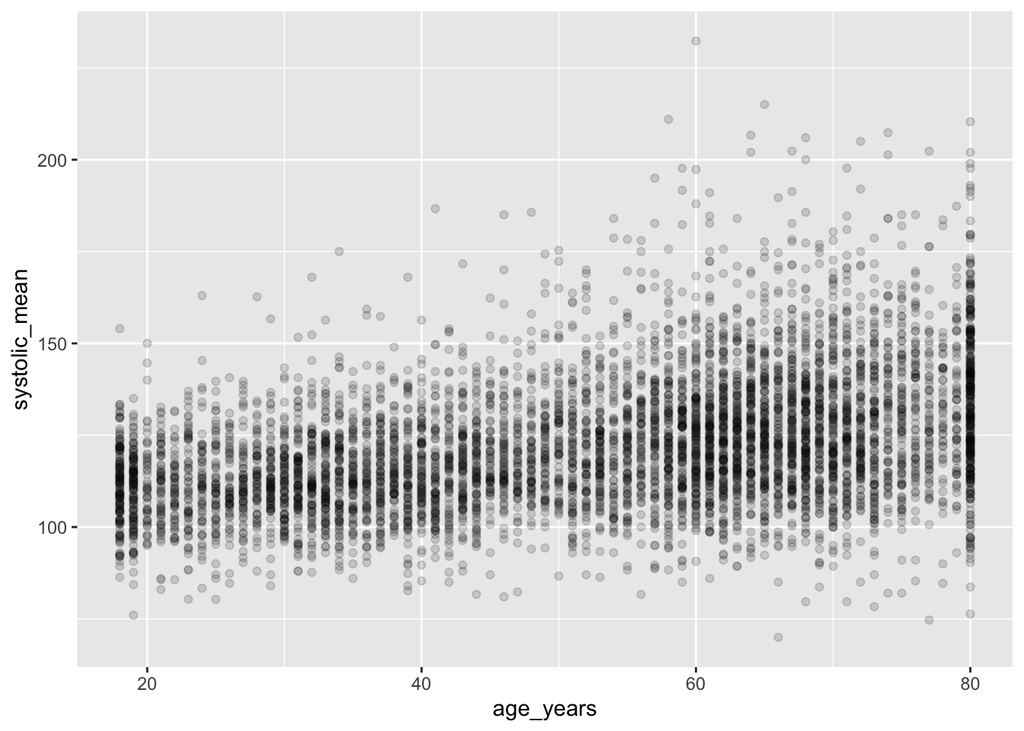

```r
p1 <- ggplot(adult_bp, aes(x = age_years, y = systolic_mean)) +
  geom_point(alpha = 0.15)

p1
```

| Plot component | Code in this chunk |
| --- | --- |
| Geoms / stats | `geom_smooth()` |
| `geom_smooth()` properties | `method = "lm"`; `se`; `color` |
| Scales / coordinates / facets / labels | `labs()`; `theme_minimal()` |

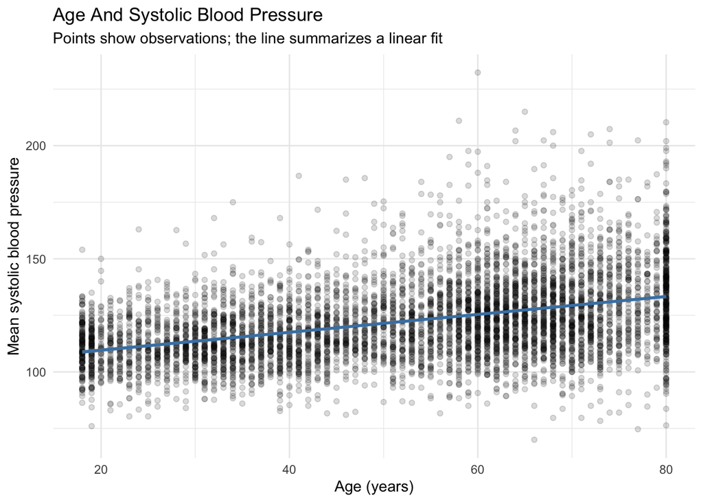

```r
p2 <- p1 +
  geom_smooth(method = "lm", se = TRUE, color = "steelblue") +
  labs(
    title = "Age And Systolic Blood Pressure",
    subtitle = "Points show observations; the line summarizes a linear fit",
    x = "Age (years)",
    y = "Mean systolic blood pressure"
  ) +
  theme_minimal()

p2
```

It is worth experimenting with the `alpha` value on scatterplots. Transparency is a powerful way to let users see where points are clustering, because the dots get “heavy.”

# Fit A Simple Model

```r
bp_model <- lm(systolic_mean ~ age_years + gender, data = adult_bp)

summary(bp_model)
```

```
Call:
lm(formula = systolic_mean ~ age_years + gender, data = adult_bp)

Residuals:
    Min      1Q  Median      3Q     Max
-60.163 -10.494  -1.553   8.431 104.538

Coefficients:
            Estimate Std. Error t value Pr(>|t|)
(Intercept) 99.74094    0.66385  150.25   <2e-16 ***
age_years    0.39464    0.01148   34.36   <2e-16 ***
gendermale   4.37547    0.41988   10.42   <2e-16 ***
---
Signif. codes:  0 '***' 0.001 '**' 0.01 '*' 0.05 '.' 0.1 ' ' 1

Residual standard error: 16.36 on 6120 degrees of freedom
Multiple R-squared:  0.1746,    Adjusted R-squared:  0.1743
F-statistic: 647.3 on 2 and 6120 DF,  p-value: < 2.2e-16
```

This model assumes the age slope is the same for each gender group. If we wanted different slopes by gender, we would need an interaction: `age_years * gender`.

# Plot Predictions

Predicted values are often more intuitive and informative when plotted than a coefficient table.

`expand.grid` is a way to create a matrix of combinations of two values, which is useful for applications like this.

```r
prediction_grid <- expand.grid(
  age_years = seq(20, 80, by = 5),
  gender = sort(unique(adult_bp$gender))
)

prediction_grid
```

```
   age_years gender
1         20 female
2         25 female
3         30 female
4         35 female
5         40 female
6         45 female
7         50 female
8         55 female
9         60 female
10        65 female
11        70 female
12        75 female
13        80 female
14        20   male
15        25   male
16        30   male
17        35   male
18        40   male
19        45   male
20        50   male
21        55   male
22        60   male
23        65   male
24        70   male
25        75   male
26        80   male
```

```r
predictions <- predict(
  bp_model,
  newdata = prediction_grid,
  interval = "confidence"
)

prediction_data <- bind_cols(
  prediction_grid,
  as.data.frame(predictions)
)

head(prediction_data)
```

```
  age_years gender      fit      lwr      upr
1        20 female 107.6338 106.7195 108.5481
2        25 female 109.6070 108.7794 110.4346
3        30 female 111.5802 110.8324 112.3280
4        35 female 113.5534 112.8761 114.2308
5        40 female 115.5267 114.9071 116.1462
6        45 female 117.4999 116.9218 118.0779
```

| Plot component | Code in this chunk |
| --- | --- |
| Aesthetic mappings | `x`; `y`; `color`; `fill`; `ymin`; `ymax` |
| Geoms / stats | `geom_ribbon()`; `geom_line()` |
| `geom_ribbon()` properties | `alpha`; `color` |
| `geom_line()` properties | `linewidth` |

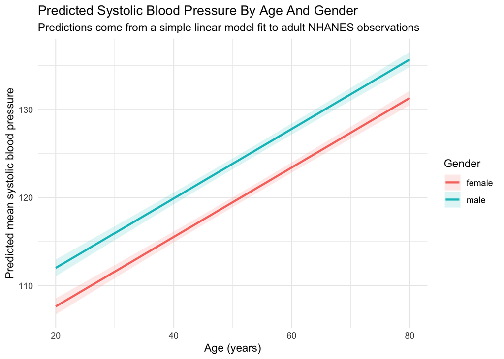

```r
p1 <- ggplot(prediction_data, aes(x = age_years, y = fit, color = gender, fill = gender)) +
  geom_ribbon(aes(ymin = lwr, ymax = upr), alpha = 0.15, color = NA) +
  geom_line(linewidth = 1)

p2 <- p1 +
  labs(
    title = "Predicted Systolic Blood Pressure By Age And Gender",
    subtitle = "Predictions come from a simple linear model fit to adult NHANES observations",
    x = "Age (years)",
    y = "Predicted mean systolic blood pressure",
    color = "Gender",
    fill = "Gender"
  ) +
  theme_minimal()

p2
```

# Show Observed Data

| Plot component | Code in this chunk |
| --- | --- |
| Aesthetic mappings | `x`; `y`; `color` |
| Geoms / stats | `geom_point()`; `geom_line()` |
| `geom_point()` properties | `alpha` |

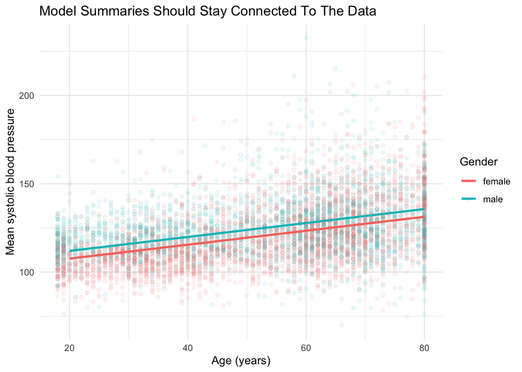

```r
p1 <- ggplot(adult_bp, aes(x = age_years, y = systolic_mean)) +
  geom_point(aes(color = gender), alpha = 0.08) +
  geom_line(
    data = prediction_data,
    aes(x = age_years, y = fit, color = gender),
    linewidth = 1
  )

p2 <- p1 +
  labs(
    title = "Model Summaries Should Stay Connected To The Data",
    x = "Age (years)",
    y = "Mean systolic blood pressure",
    color = "Gender"
  ) +
  theme_minimal()

p2
```

# Plot An Interaction

An interaction lets the age slope differ by gender. In formula notation, `age_years * gender` expands to `age_years + gender + age_years:gender`.

The coefficient table can tell us that an interaction is in the model, but a prediction plot makes the pattern easier to inspect.

```r
bp_interaction_model <- lm(systolic_mean ~ age_years * gender, data = adult_bp)

summary(bp_interaction_model)
```

```
Call:
lm(formula = systolic_mean ~ age_years * gender, data = adult_bp)

Residuals:
    Min      1Q  Median      3Q     Max
-58.215 -10.403  -1.345   8.361 105.616

Coefficients:
                     Estimate Std. Error t value Pr(>|t|)
(Intercept)          93.17964    0.85798  108.60   <2e-16 ***
age_years             0.52010    0.01551   33.53   <2e-16 ***
gendermale           18.55557    1.26422   14.68   <2e-16 ***
age_years:gendermale -0.27040    0.02277  -11.88   <2e-16 ***
---
Signif. codes:  0 '***' 0.001 '**' 0.01 '*' 0.05 '.' 0.1 ' ' 1

Residual standard error: 16.17 on 6119 degrees of freedom
Multiple R-squared:  0.1932,    Adjusted R-squared:  0.1928
F-statistic: 488.4 on 3 and 6119 DF,  p-value: < 2.2e-16
```

Use the same prediction grid as before, but ask for predictions from the interaction model.

```r
interaction_predictions <- predict(
  bp_interaction_model,
  newdata = prediction_grid,
  interval = "confidence"
)

interaction_prediction_data <- bind_cols(
  prediction_grid,
  as.data.frame(interaction_predictions)
)

head(interaction_prediction_data)
```

```
  age_years gender      fit      lwr      upr
1        20 female 103.5816 102.4570 104.7062
2        25 female 106.1821 105.1875 107.1767
3        30 female 108.7826 107.9109 109.6544
4        35 female 111.3831 110.6236 112.1427
5        40 female 113.9836 113.3202 114.6471
6        45 female 116.5841 115.9929 117.1754
```

| Plot component | Code in this chunk |
| --- | --- |
| Aesthetic mappings | `x`; `ymin`; `ymax`; `fill`; `y`; `color` |
| Geoms / stats | `geom_ribbon()`; `geom_line()` |
| `geom_ribbon()` properties | `alpha`; `color` |

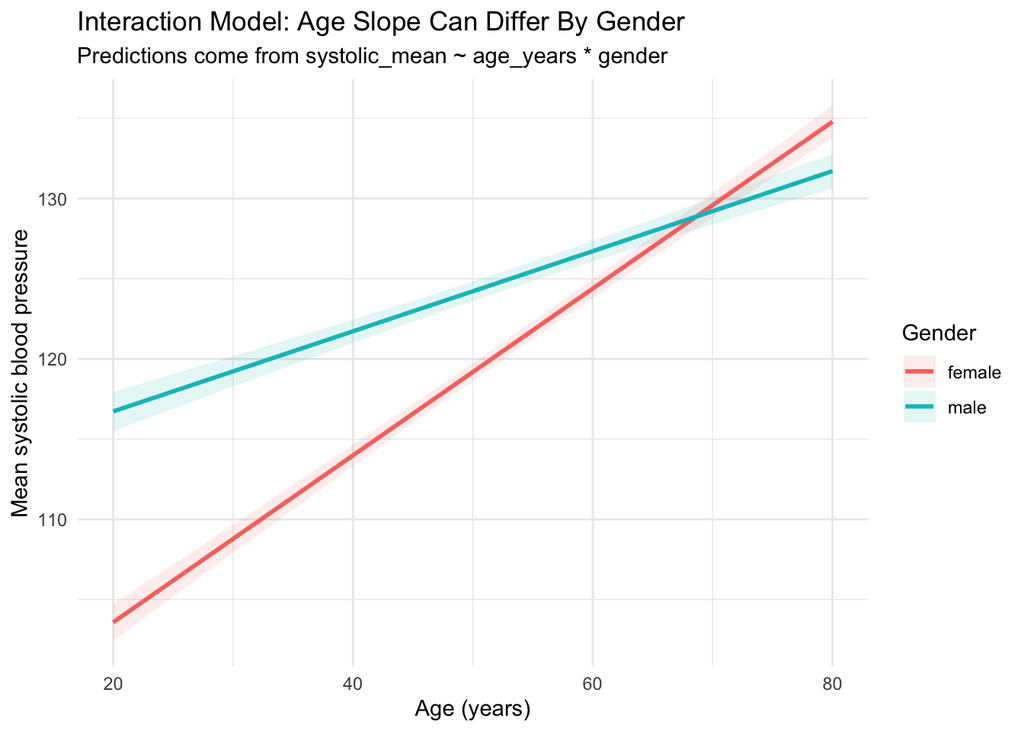

```r
ggplot() +
  geom_ribbon(
    data = interaction_prediction_data,
    aes(x = age_years, ymin = lwr, ymax = upr, fill = gender),
    alpha = 0.12,
    color = NA,
    inherit.aes = FALSE
  ) +
  geom_line(
    data = interaction_prediction_data,
    aes(x = age_years, y = fit, color = gender),
    linewidth = 1
  ) +
  labs(
    title = "Interaction Model: Age Slope Can Differ By Gender",
    subtitle = "Predictions come from systolic_mean ~ age_years * gender",
    x = "Age (years)",
    y = "Mean systolic blood pressure",
    color = "Gender",
    fill = "Gender"
  ) +
  theme_minimal()
```

This is the same visualization strategy as before: plot raw data, create prediction data, and draw the model result. The difference is that the model now allows the fitted lines to have different slopes.

# Plot A Continuous-By-Continuous Interaction

The previous interaction used one continuous predictor, `age_years`, and one categorical predictor, `gender`. Interactions can also involve two continuous predictors.

Here, the model asks whether the age slope differs across values of `family_income_to_poverty`.

| Data preparation step | Functions in this chunk |
| --- | --- |
| Keep or remove rows | `filter()` |

```r
adult_bp_income <- adult_bp |>
  filter(!is.na(family_income_to_poverty))

continuous_interaction_model <- lm(
  systolic_mean ~ age_years * family_income_to_poverty,
  data = adult_bp_income
)

summary(continuous_interaction_model)
```

```
Call:
lm(formula = systolic_mean ~ age_years * family_income_to_poverty,
    data = adult_bp_income)

Residuals:
    Min      1Q  Median      3Q     Max
-56.640 -10.611  -1.415   8.941 104.990

Coefficients:
                                     Estimate Std. Error t value Pr(>|t|)
(Intercept)                        101.032849   1.317125  76.707  < 2e-16 ***
age_years                            0.450903   0.024635  18.304  < 2e-16 ***
family_income_to_poverty             0.373329   0.419899   0.889  0.37399
age_years:family_income_to_poverty  -0.021153   0.007733  -2.735  0.00625 **
---
Signif. codes:  0 '***' 0.001 '**' 0.01 '*' 0.05 '.' 0.1 ' ' 1

Residual standard error: 16.45 on 5327 degrees of freedom
Multiple R-squared:  0.1579,    Adjusted R-squared:  0.1575
F-statistic:   333 on 3 and 5327 DF,  p-value: < 2.2e-16
```

For two continuous predictors, the coefficient table is especially hard to read directly. One of the best ways to understand the interaction is to plot predicted values across the range of one predictor while holding the other predictor at a few meaningful values.

| Data preparation step | Functions in this chunk |
| --- | --- |
| Create or change columns | `mutate()` |

```r
continuous_prediction_grid <- expand.grid(
  age_years = seq(20, 80, by = 2),
  family_income_to_poverty = c(1, 2.5, 5)
) |>
  mutate(
    income_to_poverty_label = factor(
      family_income_to_poverty,
      levels = c(1, 2.5, 5),
      labels = c(
        "Income-to-poverty ratio 1.0",
        "Income-to-poverty ratio 2.5",
        "Income-to-poverty ratio 5.0"
      )
    )
  )

continuous_interaction_predictions <- predict(
  continuous_interaction_model,
  newdata = continuous_prediction_grid,
  interval = "confidence"
)

continuous_interaction_prediction_data <- bind_cols(
  continuous_prediction_grid,
  as.data.frame(continuous_interaction_predictions)
)

head(continuous_interaction_prediction_data)
```

```
  age_years family_income_to_poverty     income_to_poverty_label      fit
1        20                        1 Income-to-poverty ratio 1.0 110.0012
2        22                        1 Income-to-poverty ratio 1.0 110.8607
3        24                        1 Income-to-poverty ratio 1.0 111.7202
4        26                        1 Income-to-poverty ratio 1.0 112.5797
5        28                        1 Income-to-poverty ratio 1.0 113.4392
6        30                        1 Income-to-poverty ratio 1.0 114.2987
       lwr      upr
1 108.7217 111.2807
2 109.6419 112.0795
3 110.5608 112.8796
4 111.4782 113.6812
5 112.3939 114.4845
6 113.3074 115.2900
```

| Plot component | Code in this chunk |
| --- | --- |
| Aesthetic mappings | `x`; `y`; `color` |
| Geoms / stats | `geom_line()` |
| Scales / coordinates / facets / labels | `coord_cartesian()`; `labs()`; `theme_minimal()` |

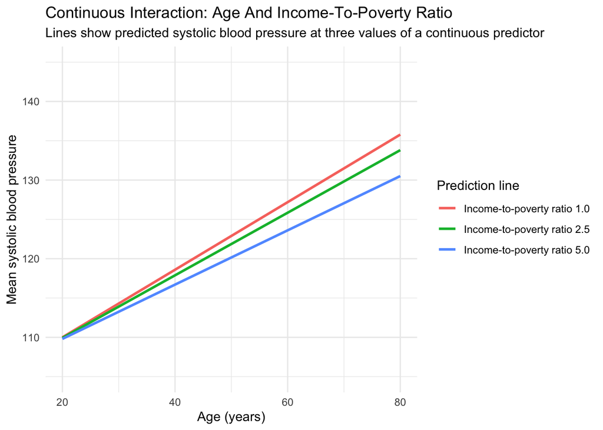

```r
ggplot(
  continuous_interaction_prediction_data,
  aes(x = age_years, y = fit, color = income_to_poverty_label)
) +
  geom_line(
    linewidth = 1
  ) +
  coord_cartesian(ylim = c(105, 145)) +
  labs(
    title = "Continuous Interaction: Age And Income-To-Poverty Ratio",
    subtitle = "Lines show predicted systolic blood pressure at three values of a continuous predictor",
    x = "Age (years)",
    y = "Mean systolic blood pressure",
    color = "Prediction line"
  ) +
  theme_minimal()
```

This kind of plot is often one of the only practical ways to understand how a continuous-by-continuous interaction is working. The interaction changes the fitted slope across a range of values and this makes it very hard to process without plotting.

# Takeaways

- Plot the data before plotting the model.
- Model plots are summaries of assumptions and fitted patterns.
- Prediction plots can be easier to interpret than coefficient tables.
- Keep model summaries connected to the data they summarize.
- Interactions are usually easier to interpret as predicted values than as coefficient-table rows.
- Continuous-by-continuous interactions often need plots to be interpreted.